# Exploratory Data Analysis of March 2025 Steam dataset

2026-09-06

We chose to work on the Steam Games Dataset 2025. From this, we selected the games_march2025_cleaned subset to explore and use for our projects.

The dataset was sourced from Kaggle, where the data was created with Steam store page scraping and Steam Games Scraper repository, which gathers data using the Steam API and Steam Spy. It consists of all the games available on the digital gaming distribution platform steam in March of 2025, and provides extensive information about each individual game.

This was of interest for us because we thought that the game data could help to build informative analysis that tells a story and shows insightful correlations. We are able to conduct both broad and specific analysis which gives us a-lot of material to work with for answering specific questions.

It consists of 89,618 rows, one per Steam application identified by `appid`, and is cross-sectional as each game is observed once at the March 2025 collection date. The variables are mixed: continuous and discrete numerical measures such as `price`, `pct_pos_total` and count variables like `dlc_count` and `peak_ccu`; binary (`windows`, `mac`, `linux`); ordinal bins (`estimated_owners`); nominal fields stored as lists (`publishers`, `genres`, `categories`, `supported_languages`); and unstructured text.

Explicit missingness is minimal, under 1% for every retained variable, the largest being `categories` at 0.9775% empty and `publishers` at 0.6104%. However, missingness is instead encoded through sentinel values which will be addressed during EDA.

We only used the games_march2025_cleaned subset of the Steam Games Dataset 2025, and did not include any of the data from the other subsets.

### Ethics, Privacy and Security

### Exploratory Data Analysis

We chose to reduce the dataset down from 47 variables to 19. This was done because, for the group section and our individual projects, some specific variables would have not contributed any additional information or provide deeper insight.

Our 19 finalized variables are;

Reduced selection of Variables from march 2025 Steam dataset

| Variables | Description |
| --- | --- |
| name | Game title |
| release_date | Release date |
| price | Price in USD |
| dlc_count | Number of DLCs avaliable |
| about_the_game | Full description of the game |
| short_description | Short description of the game |
| windows | Windows support |
| mac | Mac support |
| linux | Linux support |
| achievements | Count of possible achievements |
| supported_languages | Supported lanuages |
| publishers | Publisher(s) |
| categories | Category tags |
| genres | Genre tags |
| estimated_owners | Estimated owners |
| average_playtime_forever | Average playtime |
| peak_ccu | Peak concurrent users |
| num_reviews_total | Total number of reviews |
| pct_pos_total | Percentage of positive reviews |

#### An interesting feature of this dataset, is that some of the variables are incredibly skewed. For example, lets take a look at Price.

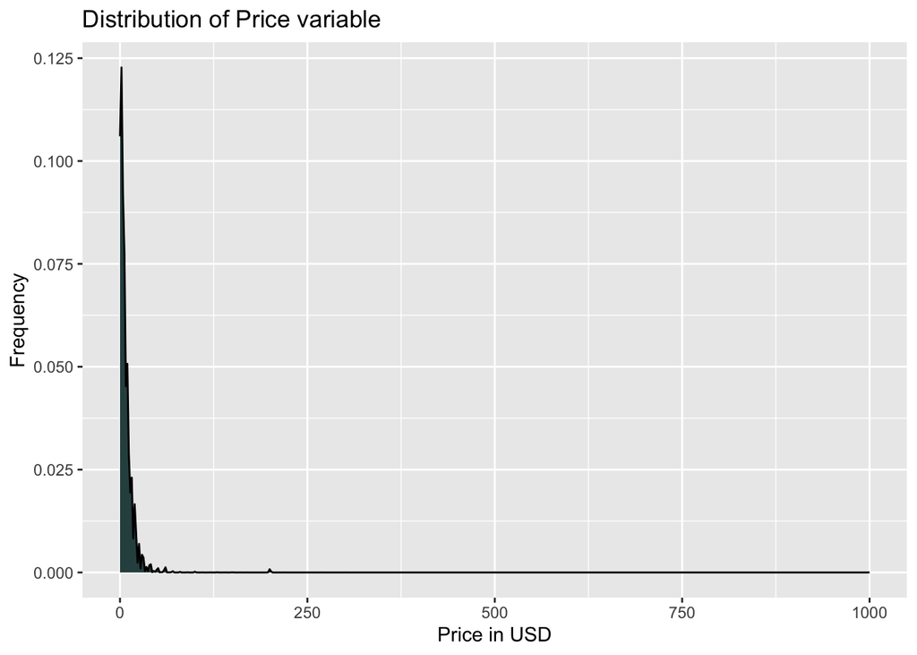

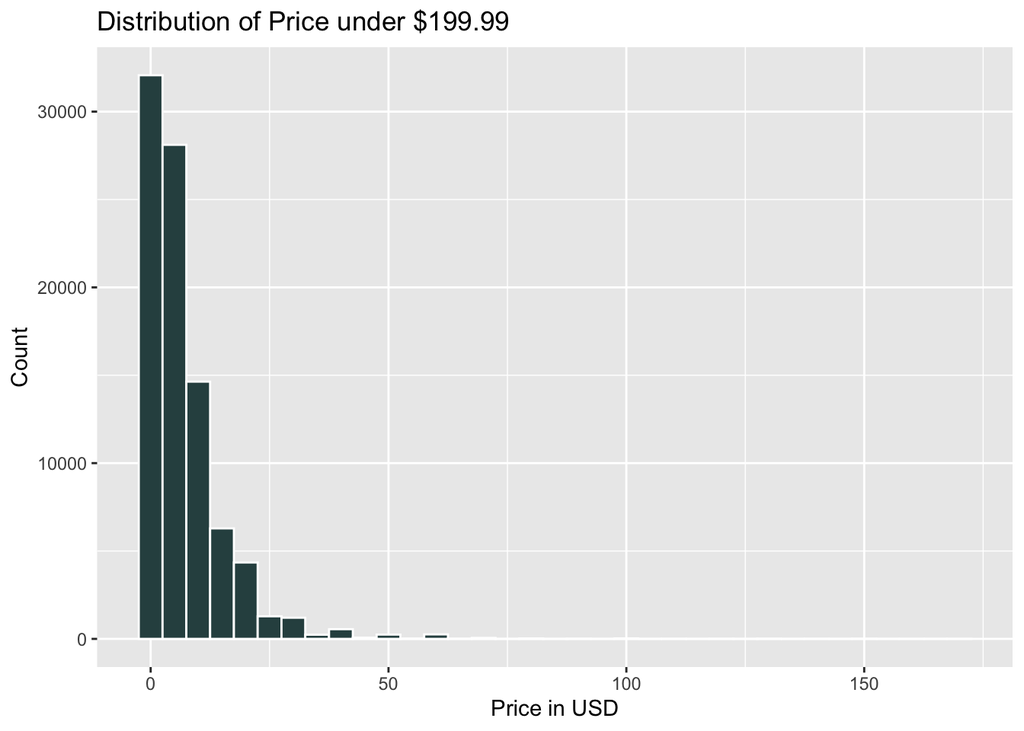

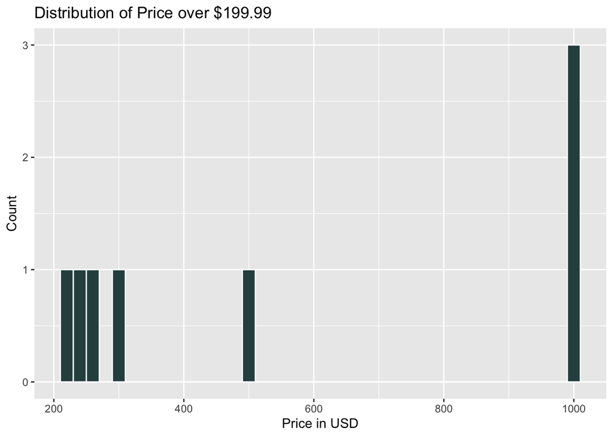

| name | price | short_description |
| --- | --- | --- |
| Beach Volleyball Competition | 219 | Beach volleyball fun game. x2 game modes, 3D or 2.5D isometric projection. Easy game play controls. Realistic ball physics and speed. Several levels, with several music. Story mode have progress for i… |
| 3DF Zephyr Lite Steam Edition | 249 | 3DF Zephyr allows you to automatically and easily create 3D models from photos: the process is completely automatic and no coded targets, manual editing or special equipments are needed: 3DF Zephyr is… |
| Houdini Indie | 270 | Houdini Indie’s procedural node-based workflow offers a smarter way to create high quality game art. Houdini technology is used by AAA studios to take their games to the next level and now this proced… |
| Aartform Curvy 3D 3.0 | 299.9 | Curvy 3D 3.0 is an innovative sculpting program for Windows, ideal for first time 3D artists. Drawing is Fast: Curvy brings new speed to 3D modelling by letting you draw shapes straight into 3D. Sculp… |
| True Love | 500 | If you are looking for the True Love… Here you go xd |
| Ascent Free-Roaming VR Experience | 999 | A premium highly-immersive VR experience developed for haptic feedback via motion floors, body suits and climate control. Go it alone or play with up to four friends in LAN co-op to destroy the infest… |
| The Leverage Game Business Edition | 1000 | You can learn realistic, world-class management techniques! The Leverage Game is an updated online version of “Leverage: The Game of Business,” an authentic business board game developed by ActionCOAC… |
| The Leverage Game | 1000 | You can learn realistic, world-class management techniques! The Leverage Game is an updated online version of “Leverage: The Game of Business,” an authentic business board game developed by ActionCOAC… |

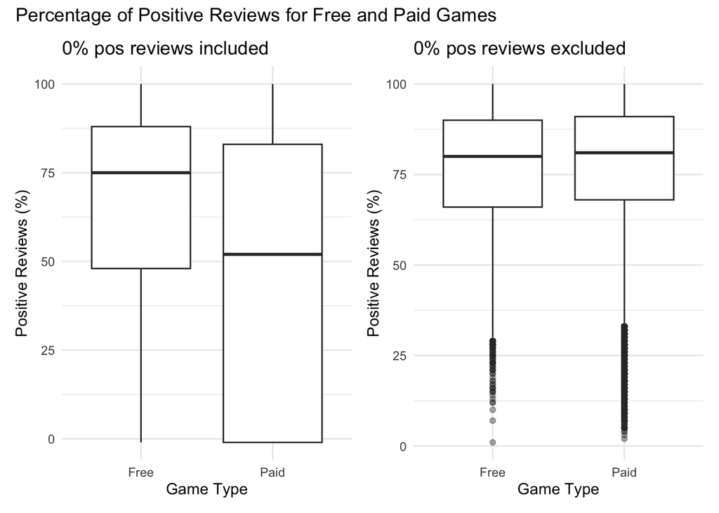

```r
steam_data <- df2 %>%
  mutate(
    price_group = ifelse(price == 0, "Free", "Paid")
  )
p1 <- ggplot(steam_data,
       aes(x = price_group,
           y = pct_pos_total)) +
  geom_boxplot() +
  labs(
    title = "0% pos reviews included",
    x = "Game Type",
    y = "Positive Reviews (%)"
  ) +

theme_minimal()


free_paid_data <- steam_data %>%
  filter(
    pct_pos_total > 0,
    price >= 0
  ) %>%
  mutate(
    game_type = ifelse(price == 0, "Free", "Paid")
  )

p2 <- ggplot(free_paid_data,
       aes(x = game_type, y = pct_pos_total)) +
  geom_boxplot(outlier.alpha = 0.4) +
  labs(
    title = "0% pos reviews excluded",
    x = "Game Type",
    y = "Positive Reviews (%)"
  ) +

theme_minimal()

(p1 + p2) + plot_annotation(
    title = "Percentage of Positive Reviews for Free and Paid Games"
  )
```

Percentage positive reviews is representing the percentage of a games total reviews that are positive. Both including and excluding games with 0% of positive reviews is represented here. which is being compared with game type of free vs games you have to pay for. We can see that for the graph including 0%, free games has a higher median of percentage of positive reviews at 75% while paid games is sitting at just above 50%. We can also see that the box plot for free games has a much smaller interquartile range (About 50-87) which showcases the middle 50% of data for free games. Paid games has a much larger interquartile range (About 0-80) showing a much larger variety of positive review percentages.

Whereas the graph excluding 0% shows that free vs paid games have very similar percentages of positive reviews. Both box plots have smaller interquartile ranges (around 65-87)than the plots that include 0%. Both plots have similar medians a bit over 75 with the paid games median being slightly higher. However, both plots contain lots of outlier points in particular the paid games. Both these graphs show how the paid games variable likely contains lots of outliers or null values which greatly effects the distribution of percentage of positive reviews. Overall if we choose to exclude the possible incorrect values we see that the the percentage of positive reviews is quite similar for free games and paid games.

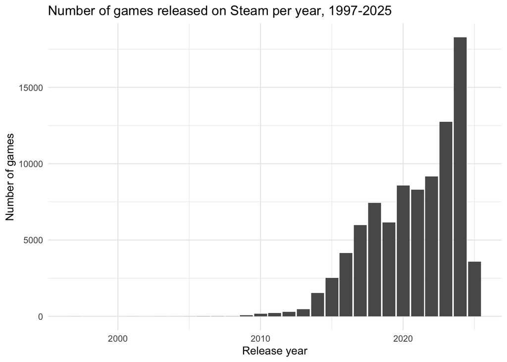

Figure 3: Number of games released on Steam per year, 1997-2025

The number of games released on Steam has increased significantly, from 1,525 titles in 2014 to 18,282 in 2024, with 2024 alone representing a 43.6% increase on the previous year. The trend is not entirely monotonic, with a decline of 17.4% in 2019. Notably, 67.6% of all games in the dataset were released from 2020 onwards, meaning the catalogue is heavily weighted towards recent titles. This growth is consistent with the lowering of barriers to publication on the platform and the increasing accessibility of game development tools, although the dataset alone cannot distinguish between such explanations. Note that the 2025 figure is low, as the data were collected in March 2025 and therefore do not capture the full year. —